# PHYS 210 Day 01 - Sep 09, 2026

Agenda:

1. General introduction & syllabus
2. Getting to know each other
3. How this course runs: lessons, tests at ORCA, projects
4. Group activities
5. Getting started with Jupyter and your Day 01 Homework

## My name: Stefan Reinsberg

- I'm faculty in the Department of Physics and Astronomy
- I use computation daily in my own work (MRI physics)
  - simulating the process of MRI data acquisition
  - image processing
- Ask us (TAs plus me) anything -- in class, on Piazza
  - no separate office hours (yet): for personal meetings, email me and we'll find some time

## What is this course all about?

Investigating physical systems with python, using simulations and numerical methods. Communicating interesting findings using Jupyter notebooks.

- Most realistic physical problems do not have exact analytical solutions.
- Problems based on simple equations (e.g., $F = ma$) become complicated with many interacting components.

## Some big-picture learning goals

Translate physical laws into computer code that can be used to perform investigations, solve problems and answer questions

- Manage files and programs on the computer
- Edit and execute programs
- Read and write data files from within a program
- Manipulate data and perform calculations within a program
- Visualize, communicate and interpret the results of calculations and investigations

## Find the detailed syllabus and more on Canvas

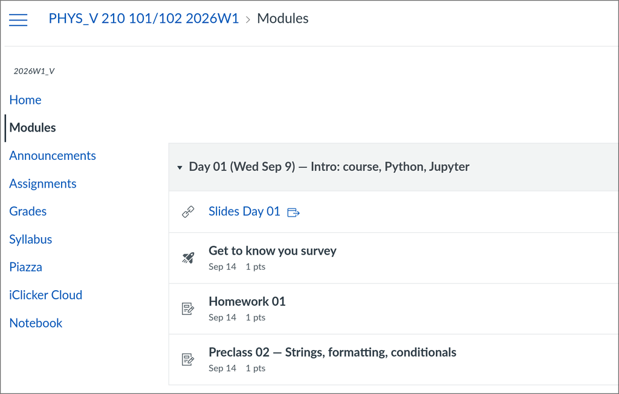

## Course schedule

- **Section 101/L1A:** Mon/Wed 13:00-13:30, 13:30-15:20 Hebb B112 (basement)
- **Section 102/L1B:** Mon/Wed 15:30-16:00, 16:00-17:50 Hebb B112 (basement)
- Please attend the section you are registered in
- Each day runs as one contiguous 2.5-hour block (the lecture/lab split is bookkeeping)

## Course format: skills first, then projects

**Weeks 1–8: skills bootcamp**

- One small, self-contained Python topic per class
- Pre-class reading → short interactive recap → group worksheet → homework
- Your skills are checked in **5 short tests** at UBC's testing centre (ORCA)

**Weeks 9–13: two real projects**

- Studio classes: you work, we (instructor + TAs) help
- Draft → feedback → revise, like real scientific work
- Each project ends with a short **defence**: you walk us through YOUR work

## How your grade works

| Component | Weight |
| --- | --- |
| 5 ORCA tests (biweekly, 10% each; one makeup window) | **50%** |
| Project A (written + defence) | 20% |
| Project B (written + defence) | 25% |
| Engagement (preclass, worksheets, homework) | 5% |

- Tests certify the skills; projects show what you can build with them
- Details in the syllabus on Canvas and in the coming lectures

## Your tests run at ORCA (more details next time)

- ORCA = UBC's Open Resource Centre for Assessments (Hennings or ICICS building)
- **You book your own 50-minute slot** within a ~4-day window (biweekly, TBC)
- First window: **Sep 28 – Oct 2** · booking opens **Mon Sep 14** (we'll book together in class!)
- Test machines: Python yes, but no internet nor AI tools
- Every test has a **practice twin** in PrairieLearn: same style, unlimited attempts, released a week ahead

## The AI deal in this course

AI assistants (ChatGPT, Claude, Copilot, ...) can write Python, but ...

- **Outside tests** (projects, homework, practice): you MAY use AI tools — with attribution
- **You are solely responsible for what you submit**: you must be able to explain, defend, and modify every line
- "The AI wrote it" is never an excuse
- **ORCA Tests are AI-free by design** make sure you know you can do the work without AI crutches **before** doing tests and project work.

## Academic integrity

**Your work should reflect YOUR intellectual contributions and understanding**

- Submit only work you understand and can explain — this is checked at the defences
- Acknowledge all sources: peers, websites, AI tools
- Copying or misrepresenting someone else's (or something else's) work as your own = academic misconduct
- Unsure whether something is OK? **Ask us first**

## Bring your own computer each day

Course tools:

| **UBC Jupyter Open** | where we write and run Python (browser-based; any laptop works) |
| --- | --- |
| **Canvas** | announcements, links, deadlines |
| **PrairieLearn** | practice questions + the ORCA tests |
| **iClicker Cloud** | in-class polling |
| **Piazza** | questions & discussion |

## iClicker Cloud for in-class polling questions

- Click on the "iClicker Cloud" link on Canvas
- If needed, make an account
  - Use this link to join the course: https://join.iclicker.com/YHIP

[figure not shown]

**Poll 1.1:** Paper to the moon.

If you fold a LARGE sheet of paper in half, its thickness doubles. Fold it in half again, the thickness doubles again. How many times would you need to fold it in half until the thickness is great enough to reach the moon?

What is your initial guess? (don’t try to calculate yet)

A) 10 - 99  
B) 100 - 999  
C) 1,000 - 9,999  
D) 10,000 - 99,999  
E) More than 100,000

## Group activities

**Group activity #1:** Work in groups of 3-4

Introduce yourselves to each other and share:

- Your name
- Your previous computing experience
- What you are looking forward to in PHYS 210

Work on a quantitative estimate to the paper folding problem in your group

- distance to the moon ~ 400,000 km

**Poll 1.2:** What was your group’s quantitative estimate?

A) 10 - 99  
B) 100 - 999  
C) 1,000 - 9,999  
D) 10,000 - 99,999  
E) More than 100,000

**Group activity #2:** A sorting algorithm

**What is an algorithm?**

- A method to solve a problem
- A set of step-by-step rules

*This activity is adapted from Michigan State University's CMSE 201*

### Example: Given a list of numbers, find the largest one

- **A defined set of inputs:** list: 3, 1, 5, 2
- **A defined set of outputs:** the largest number
- **A precise set of step-by-step instructions:** next slide

### Step-by-step instructions with example numbers (3, 1, 5, 2)

1. Start with the first number and assume it's the largest: **3**
2. Compare the current largest number with the next number in the list: **3 vs 1**
3. If the next number is larger, make it the new largest number: **3**
4. Repeat steps 2 and 3 until you've checked all the numbers. **3 vs 5, 5 is largest. 5 vs 2, 5 is largest**
5. The largest number you found is the answer. **5 is the largest number**

**As a group, design an algorithm that sorts a group of people by their birthday (Jan 1st to Dec 31st). The algorithm can ask only yes/no questions. (Paper only)**

- **Inputs:** a set of people, in a given (random) order.
- **Outputs:** the same set of people, arranged by birthday.
- The algorithm can change the order of people in the list and can ask for information using only yes/no questions, such as "Were you born in July?" or "Were you born on February 2nd?"

Test it on your group after you are done designing it. How many questions did it have to ask? Afterward compare with 1-2 other groups and see which algorithm asks the fewest questions.

**(Time permitting) Reflect with your group on the following:**

- What worked well and what didn't?
- Are there ways to make your algorithm work more efficiently?
- Which algorithm worked the best and why?
- What if the individuals that you were trying to sort could ask questions of each other?

## Get to know you survey (on Canvas)

- In the **Day 01 module** on Canvas: "Get to know you survey"
- ~7 minutes, 10 quick questions — helps us tailor the course and group tables sensibly
- Includes questions about your experience with **AI coding tools** — answer honestly; there are no wrong answers and you're not held to any of it
- Counts as your **Day 01 engagement point** (full credit for completing it)
- Due **Mon Sep 14, 9 am** (with Homework 01 and Preclass 02)

## A brief tour of Jupyter Open and getting started on your Day 01 Homework

- Use the Canvas links, such as "Homework Day 01", which will open the desired file, whole synchronizing all handouts from our repository to your Jupyter Open account in the background
- Submit exported notebooks as html files on Canvas
- You can always access your work at https://open.jupyter.ubc.ca/

## Optional: run the same notebook on your own laptop (`uv`)

Jupyter Open stays the course default — this is for working offline.

**1. Install `uv` (once)**

- macOS — in **Terminal**:

```
curl -LsSf https://astral.sh/uv/install.sh | sh
```

- Windows — in **PowerShell**:

```
powershell -ExecutionPolicy ByPass -c "irm https://astral.sh/uv/install.ps1 | iex"
```

Close the terminal and open a new one afterwards.

## Optional: run the same notebook on your own laptop (`uv`) — continued

**2. Fire up Jupyter for a single notebook**

`cd` into the folder that holds the file, then:

```
uv run --with jupyter jupyter lab HW01.ipynb
```

- `uv` downloads Python and Jupyter on the fly — no `pip`, no environment to manage.
- Need libraries? `uv run --with jupyter --with numpy --with matplotlib jupyter lab HW01.ipynb`
- `Ctrl-C` in the terminal shuts the server down.

## Use of `assert` to get feedback on many of our tasks

```python
animal = "cat"

assert animal == "dog", "you chose the incorrect answer"
print("yay, you passed")
```

## What happens when you change the animal?

```python
animal = "dog"

assert animal == "dog", "you chose the incorrect answer"
print("yay, you passed")
```

**Until the end of class and before Monday's class:**

- Complete **Day 01 Homework** and submit on Canvas (due Mon Sep 14, 9 am)
- Complete the **"Get to know you survey"** on Canvas (Day 01 module, due Mon 9 am)
- Do the **Preclass 02 reading** (strings & conditionals) — due Mon 9 am
- Monday in class: we book your **Test 1 ORCA slot together** (bring your laptop!)